# Le lien entre salaire et productivité est-il confirmé ?

Caboul Emma, Limane Frederique Claudia, Tchakah Abra

2025-12-09

## 0.1 Dataset Description

Les données utilisées pour notre projet proviennent essentiellement d’**Eurostat**.

Ce dataset permet d’observer et **d’étudier** le lien entre croissance de la productivité et évolution des salaires, et d’identifier des différences structurelles entre pays à travers diverses périodes.

Notre objectif est de voir si le lien entre productivité et salaire se confirme toujours. Pour **ce** faire, nous avons décidé de découper **la période d’analyse** en trois tranches :

- **2000-2007** : Précédant la crise des subprimes
- **2008-2019** : Après la crise des subprimes et avant la crise du Covid-19
- **2020-2025** : Covid et post-Covid

# 1 Variables disponibles

Dans le cadre de l’analyse, on va nettoyer l’environnement R et charger les librairies nécessaires à notre étude sur le lien entre productivité et salaire dans les pays de l’Union européenne entre 2000 et 2025.

On va importer tout un ensemble de packages nous permettant d’importer nos données Excel, de les manipuler, d’effectuer des visualisations comparatives, et d’estimer les modèles économétriques utilisés dans le projet.

## 1.1 Configuration de l’environnement et description des données

Avant de commencer, on doit charger les bibliothèques ‘library’ qu’on va utiliser dans notre projet.

Dans ce projet, nous utilisons les librairies suivantes :

- `dplyr` : manipulation des données (select, filter, mutate) pour construire nos variables de salaire, productivité, R&D, éducation et inflation.
- `tidyr` : restructuration des tableaux (pivot_longer, pivot_wider) pour aligner les séries temporelles sur les 27 pays.
- `ggplot2` : visualisations graphiques (évolution des salaires, dispersion salaire-productivité, tendances par période).
- `readxl` : importation des fichiers Excel provenant d’Eurostat et téléchargés dans notre dossier.
- `corrplot` : représentation graphique des matrices de corrélation entre variables macroéconomiques.
- `stargazer` : création de tableaux de statistiques descriptives et de régressions dans le format du rapport final.
- `broom` : mise en forme et extraction propre des résultats des modèles économétriques (tidy, augment).
- `sandwich` : calcul d’erreurs standards robustes afin de corriger les problèmes d’hétéroscédasticité ou d’autocorrélation.
- `ggrepel` : amélioration de la lisibilité des graphiques en évitant le chevauchement des étiquettes.
- `janitor` : nettoyage des données et standardisation des noms de variables issues des fichiers Excel.
- `AER` : outils économétriques complémentaires utilisés dans un cadre appliqué.

Cette étape de préparation assure une structure propre et reproductible de notre environnement de travail, permettant de mener l’analyse de manière cohérente et rigoureuse.

# 2 Introduction

## 2.1 Contexte économique et motivation

Depuis le début des années 2000, l’Union européenne a traversé trois crises économiques majeures qui ont profondément marqué les trajectoires de croissance des États membres : la crise financière mondiale de 2008, la crise des dettes souveraines en zone euro (2010-2012), et plus récemment la pandémie de Covid-19 (2020-2021). Durant cette période de 25 années, un phénomène préoccupant a émergé dans les débats économiques et sociaux : **le découplage progressif entre la croissance de la productivité du travail et l’évolution des salaires réels**.

Selon la théorie économique néoclassique, les salaires réels devraient évoluer en proportion de la productivité marginale du travail dans un marché concurrentiel. En d’autres termes, lorsque la productivité augmente de 1%, les salaires devraient également augmenter de 1%, reflétant ainsi une **élasticité unitaire** de la rémunération par rapport à la productivité. Cette relation est au cœur du partage équitable de la valeur créée entre les facteurs de production : capital et travail.

Cependant, les observations empiriques récentes dans les économies développées, et notamment au sein de l’Union européenne, suggèrent un **affaiblissement progressif de ce lien**. Les gains de productivité ne se traduisent plus intégralement en augmentations salariales, soulevant des questions majeures :

- **Distribution des revenus** : Si les salaires stagnent alors que la productivité augmente, qui capte les gains de croissance ? Les profits des entreprises ? Les revenus du capital ?
- **Inégalités croissantes** : Le creusement observé entre revenus du capital et revenus du travail contribue-t-il à l’augmentation des inégalités économiques ?
- **Cohésion sociale** : La stagnation du pouvoir d’achat malgré les gains de productivité peut-elle engendrer des tensions sociales et une remise en cause du modèle économique européen ?

## 2.2 Problématique de recherche

Face à ces constats préoccupants, notre étude pose la question centrale suivante :

> **“Dans quelle mesure le lien entre productivité et salaire s’est-il maintenu dans l’Union européenne entre 2000 et 2025 ?”**

**Plus précisément**, nous testons si les salaires évoluent en proportion de la productivité, conformément à la **théorie néoclassique** qui postule que les salaires réels devraient refléter la productivité marginale du travail. Cette question se distingue de la causalité inverse (impact des salaires sur la productivité), qui relève des théories du salaire d’efficience et n’est pas l’objet de cette étude. Cette problématique nous conduit à structurer notre analyse empirique autour de **trois sous-questions complémentaires** :

### 2.2.1 Sous-question 1 : Évolution temporelle de l’élasticité

> **L’élasticité du salaire par rapport à la productivité a-t-elle évolué entre les trois périodes distinctes** que nous identifions : - **Pré-crise financière** (2000-2007) - **Post-crise financière** (2008-2019) - **Période récente incluant la pandémie** (2020-2025) ?

Nous cherchons à quantifier précisément le degré de découplage et à identifier à quel moment historique celui-ci s’est intensifié.

### 2.2.2 Sous-question 2 : Robustesse causale et facteurs explicatifs

> **Le lien observé entre salaires et productivité résiste-t-il au contrôle rigoureux de l’endogénéité** et à l’inclusion de facteurs institutionnels et structurels tels que : - L’investissement en recherche et développement (R&D) - Le niveau d’éducation de la population active - L’inflation et son impact sur les salaires réels - La structure sectorielle de l’économie (part de l’industrie)

Cette question vise à établir un lien **causal** plutôt que simplement corrélationnel.

### 2.2.3 Sous-question 3 : Hétérogénéité géographique

> **Existe-t-il des différences significatives dans cette relation entre les différents groupes de pays européens** ?

Nous distinguerons notamment : - Le **“Core” européen** (Allemagne, France, Pays-Bas, Belgique, Autriche, Luxembourg) - L’**Europe du Nord** (Danemark, Finlande, Suède) - L’**Europe du Sud** (Espagne, Italie, Grèce, Portugal, Chypre, Malte) - L’**Europe de l’Est** (pays ayant rejoint l’UE après 2004)

## 2.3 Stratégie empirique

### 2.3.1 Variables analysées

**Variable dépendante :** - **Salaire horaire moyen** (en logarithme) : log(wage)

**Variable explicative principale :** - **Productivité du travail** (PIB par heure travaillée, en logarithme) : log(prod)

**Variables de contrôle :** - **Dépenses en R&D** (% du PIB) : rd - **Niveau d’éducation tertiaire** (% de la population 25-64 ans) : educ - **Inflation** (Indice harmonisé des prix à la consommation, HICP) : inflation - **Part industrielle** (% de la valeur ajoutée) : ind_share

### 2.3.2 Méthodologie économétrique

Notre stratégie empirique repose sur une **approche progressive et rigoureuse** :

**1. Modèles OLS simples et multiples** - Estimation de l’élasticité de base par période - Spécifications log-log pour interpréter les coefficients comme des élasticités

**2. Modèles à effets fixes panel** - Contrôle de l’hétérogénéité inobservée constante dans le temps - Test de Hausman pour comparer effets fixes vs effets aléatoires

**3. Variables instrumentales (IV/2SLS)** - Traitement de l’endogénéité potentielle - Instruments : productivité retardée (t-2), R&D retardé (t-2), part industrielle retardée (t-2)

**4. Tests de robustesse** - Tests d’hétéroscédasticité et d’autocorrélation - Erreurs standard robustes (HC1, HAC)

## 2.4 Contributions de l’étude

Notre recherche apporte **quatre contributions principales** :

1. **Actualité des données** : Inclusion de la période post-Covid jusqu’en 2025
2. **Périodisation pertinente** : Découpage reflétant les chocs macroéconomiques
3. **Rigueur méthodologique** : Traitement systématique de l’endogénéité
4. **Analyse comparative** : Identification des différences entre pays

## 2.5 Structure du document

- **Section II** : Données et statistiques descriptives
- **Section III** : Résultats économétriques (OLS, effets fixes, IV)
- **Section IV** : Tests de robustesse
- **Section V** : Analyses complémentaires
- **Section VI** : Discussion des résultats
- **Section VII** : Conclusion

##Configuration et chargement des packages

```r
library(tidyverse)
```

```r
library(dplyr)
library(tidyr)
library(ggplot2)
library(stargazer)
library(corrplot)
library(janitor)
library(readxl)
library(stringr)
library(broom)
library(AER)
library(sandwich)
library(ggrepel)
library(lmtest)
library(plm)
library(zoo)
library(kableExtra)
library(forcats)
library(flextable)
```

# 3 Données

## 3.1 Sources

- **Salaires** : Salaires horaires moyens
- **Productivité** : Productivité du travail (PIB par heure travaillée)
- **R&D** : Dépenses en recherche et développement (% du PIB)
- **Éducation** : Part de la population avec éducation tertiaire
- **Inflation** : Indice harmonisé des prix à la consommation (HICP)
- **Part industrielle** : Part de l’industrie dans la valeur ajoutée

#Définition des pays et harmonisation

```r
country_order <- c(
  "Belgium","Bulgaria","Czechia","Denmark","Germany","Estonia","Ireland","Gre
ece",
  "Spain","France","Croatia","Italy","Cyprus","Latvia","Lithuania","Luxembour
g",
  "Hungary","Malta","Netherlands","Austria","Poland","Portugal","Romania",
  "Slovenia","Slovakia","Finland","Sweden"
)
country_map <- c(
  "Belgique"="Belgium","Bulgarie"="Bulgaria","Tchéquie"="Czechia","Danemark"=
"Denmark",
  "Allemagne"="Germany","Estonie"="Estonia","Irlande"="Ireland","Grèce"="Gree
ce",
  "Espagne"="Spain","France"="France","Croatie"="Croatia","Italie"="Italy",
  "Chypre"="Cyprus","Lettonie"="Latvia","Lituanie"="Lithuania","Luxembourg"="
Luxembourg",
  "Hongrie"="Hungary","Malte"="Malta","Pays-Bas"="Netherlands","Autriche"="Au
stria",
  "Pologne"="Poland","Portugal"="Portugal","Roumanie"="Romania",
  "Slovénie"="Slovenia","Slovaquie"="Slovakia","Finlande"="Finland","Suède"="
Sweden"
)
```

## 3.2 Chargement des données

```r
paths <- list(
  wage   ="/Users/user/Downloads/09912845-6cdb-46a0-bac1-585892f79461 (1).xlsx",
  hicp   = "/Users/user/Downloads/prc_hicp_aind__custom_19231278_spreadsheet (1).xlsx",
  rd     = "/Users/user/Downloads/rd_e_gerdtot__custom_19231262_spreadsheet (1).xlsx",
  educ   ="/Users/user/Downloads/edat_lfs_9903__custom_19231228_spreadsheet (1).xlsx",
  ind    = "/Users/user/Downloads/ind_share.xlsx",
  prod   = "/Users/user/Downloads/nama_10_lp_ulc__custom_19231129_spreadsheet (1).xlsx"
)
```

```r
# On decide de filtrer et de nettoyer la data

wage_raw <- read_excel(paths$wage, sheet = "Sheet1") %>% clean_names()
hicp_raw  <- read_excel(paths$hicp, sheet = 1, skip = 27)%>% clean_names()
rd_raw    <- read_excel(paths$rd, sheet = 1, skip = 22)%>% clean_names()
educ_raw  <- read_excel(paths$educ, sheet = 1, skip = 20)%>% clean_names()
ind_raw   <- read_excel(paths$ind, sheet = 1)%>% clean_names()
prod_raw  <- read_excel(paths$prod, sheet = 1, skip = 24)%>% clean_names()
```

## 3.3 Fonction de nettoyage

```r
clean_eurostat <- function(path, skip_header, skip_data, varname) {
  hdr <- read_excel(path, sheet = 1, skip = skip_header, n_max = 1)
  years <- names(hdr)[str_detect(names(hdr), "^[0-9]{4}$")]
  raw <- read_excel(path, sheet = 1, skip = skip_data, col_names = FALSE)

  df <- tibble(
    country = raw[[1]],
    !!!set_names(lapply(seq_along(years), function(i) as.character(raw[[i+1]])), years)
  )

  df_long <- df %>%
    pivot_longer(-country, names_to = "year", values_to = varname) %>%
    mutate(
      year = as.integer(year),
      !!varname := suppressWarnings(as.numeric(.data[[varname]]))
    )

  return(df_long)
}
```

## 3.4 Nettoyage et préparation

```r
# Salaire
wage_raw <- read_excel(paths$wage, sheet = "Sheet1") %>% clean_names()
wage_long <- wage_raw %>%
  select(country, starts_with("x")) %>%
  pivot_longer(-country, names_to = "year", values_to = "wage") %>%
   mutate(year = as.integer(str_remove(year, "x"))) %>%
  filter(country %in% country_order)
#Inflation
hdr <- read_excel(paths$hicp, sheet = 1, skip = 7, n_max = 1)
years <- names(hdr)[str_detect(names(hdr), "^[0-9]{4}$")]
raw <- read_excel(paths$hicp, sheet = 1, skip = 10, col_names = FALSE)
hicp_clean <- tibble(
  country = raw[[1]],
  !!!set_names(lapply(seq_along(years), function(i) as.character(raw[[i+1]])), years)
)
hicp_long <- hicp_clean %>%
  mutate(across(-country, as.character)) %>%
  pivot_longer(-country, names_to = "year", values_to = "inflation") %>%
  mutate(
    year = as.integer(year),
    inflation = suppressWarnings(as.numeric(inflation))
  )
# R&D
rd_long   <- clean_eurostat(paths$rd,   skip_header = 7, skip_data = 10, varname = "rd")
# Education
educ_long <- clean_eurostat(paths$educ, skip_header = 9, skip_data = 13, varname = "educ")
# Productivité
prod_long <- clean_eurostat(paths$prod, skip_header = 7, skip_data = 10, varname = "prod")
#Part industrielle
pind_raw <- read_excel(paths$ind, sheet = 1) %>% clean_names()
ind_long <- ind_raw %>%
  rename(country = times) %>%
  pivot_longer(cols = starts_with("x"), names_to = "year", values_to = "ind_share") %>%
  mutate(year = as.integer(str_remove(year, "x")),
         ind_share = suppressWarnings(as.numeric(ind_share)),
         country = country_map[country])
```

# 4 Création du panel complet

```r
# ÉTAPE 1 : Nettoyage de CHAQUE table AVANT les jointures
wage_long <- wage_long %>% distinct(country, year, .keep_all = TRUE)
hicp_long <- hicp_long %>% distinct(country, year, .keep_all = TRUE)
rd_long <- rd_long %>% distinct(country, year, .keep_all = TRUE)
educ_long <- educ_long %>% distinct(country, year, .keep_all = TRUE)
prod_long <- prod_long %>% distinct(country, year, .keep_all = TRUE)
ind_long <- ind_long %>% distinct(country, year, .keep_all = TRUE)

# ÉTAPE 2 : les jointures
panel <- wage_long %>%
  left_join(hicp_long, by = c("country","year")) %>%
  left_join(rd_long, by = c("country","year")) %>%
  left_join(educ_long, by = c("country","year")) %>%
  left_join(prod_long, by = c("country","year")) %>%
  left_join(ind_long, by = c("country","year"))

# ÉTAPE 3 : Supprimer les doublons après jointures
panel <- panel %>%
  distinct(country, year, .keep_all = TRUE)
panel <- panel %>%
  filter(country %in% country_order) %>%
  filter(year >= 2000 & year <= 2025) %>%
  arrange(country, year) %>%
  mutate(
    wage_log = log(wage),
    prod_log = log(prod),
    rd_log = log(rd)
  )

# Vérification
cat("Dimensions du panel :", nrow(panel), "observations,", ncol(panel), "variables\n")
```

```
## Dimensions du panel : 624 observations, 11 variables
```

```r
cat("Période :", min(panel$year, na.rm=TRUE), "-", max(panel$year, na.rm=TRUE), "\n")
```

```
## Période : 2000 - 2025
```

```r
cat("Nombre de pays :", n_distinct(panel$country), "\n")
```

```
## Nombre de pays : 24
```

## 4.1 Création des instruments

Pour traiter l’endogénéité potentielle, nous créons des variables instrumentales basées sur des valeurs retardées :

```r
panel <- panel %>%
  group_by(country) %>%
  arrange(year) %>%
  mutate(
    # Productivité retardée (instruments)
    prod_log_lag1 = lag(prod_log, 1),
    prod_log_lag2 = lag(prod_log, 2),
    prod_log_lag3 = lag(prod_log, 3),

    # R&D retardé (instruments)
    rd_lag1 = lag(rd, 1),
    rd_lag2 = lag(rd, 2),
    rd_log_lag2 = lag(rd_log, 2),

    # Part industrielle retardée (instrument)
    ind_share_lag1 = lag(ind_share, 1),
    ind_share_lag2 = lag(ind_share, 2),

    # Terme quadratique pour non-linéarité
    prod_log_sq = prod_log^2
  ) %>%
  ungroup()

cat("\n=== Aperçu des instruments créés ===\n")
```

```
##
## === Aperçu des instruments créés ===
```

```r
summary(panel %>% select(prod_log_lag2, rd_lag2, ind_share_lag2))
```

```
##  prod_log_lag2      rd_lag2       ind_share_lag2
##  Min.   :3.821   Min.   :0.2300   Min.   : 6.72
##  1st Qu.:4.412   1st Qu.:0.6225   1st Qu.:17.09
##  Median :4.519   Median :1.1150   Median :20.54
##  Mean   :4.472   Mean   :1.4039   Mean   :20.63
##  3rd Qu.:4.570   3rd Qu.:2.0675   3rd Qu.:24.49
##  Max.   :4.676   Max.   :3.8700   Max.   :40.24
##  NA's   :312     NA's   :318      NA's   :74
```

# 5 Sous-panels par periode

```r
panel_2000_2007 <- panel %>%
 filter(year >= 2000, year <= 2007) %>%
  mutate(tranche = "2000-2007", prod_log_sq = prod_log^2)

panel_2008_2019 <- panel %>%
 filter(year >= 2008, year <= 2019) %>%
  mutate(tranche = "2008-2019", prod_log_sq = prod_log^2)

panel_2020_2025 <- panel %>%
 filter(year >= 2020, year <= 2025) %>%
  mutate(tranche = "2020-2025", prod_log_sq = prod_log^2)

panel_all <- bind_rows(panel_2000_2007, panel_2008_2019, panel_2020_2025)

cat("Observations par période :\n")
```

```
## Observations par période :
```

```r
cat("  2000-2007 :", nrow(panel_2000_2007), "\n")
```

```
##   2000-2007 : 192
```

```r
cat("  2008-2019 :", nrow(panel_2008_2019), "\n")
```

```
##   2008-2019 : 288
```

```r
cat("  2020-2025 :", nrow(panel_2020_2025), "\n")
```

```
##   2020-2025 : 144
```

## 5.1 Statistiques descriptives et corrélations

# 6 Descriptives par tranche

```r
vars <- c("wage","prod","educ","rd","inflation","ind_share")
desc_all <- panel_all %>%
  group_by(tranche) %>%
  summarise(across(all_of(vars),
                   list(Moyenne = ~mean(.x, na.rm=TRUE),
                        Ecart_type = ~sd(.x, na.rm=TRUE),
                        Min = ~min(.x, na.rm=TRUE),
                        Max = ~max(.x, na.rm=TRUE)),
                   .names = "{.col}_{.fn}"))

kable(desc_all, digits = 2, caption = "Statistiques descriptives par période") %>%
  kable_styling(bootstrap_options = c("striped", "hover"))
```

Statistiques descriptives par période

| tranche | wage_Moyenne | wage_Ecart_type | wage_Min | wage_Max | prod_Moyenne | prod_Ecart_type | prod_Min | prod_Max | educ_Moyenne | educ_Ecart_type | educ_Min | educ_Max | rd_Moyenne | rd_Ecart_type | rd_Min | rd_Max | inflation_Moyenne | inflation_Ecart_type | inflation_Min | inflation_Max | ind_share_Moyenne | ind_share_Ecart_type | ind_share_Min | ind_share_Max |
| --- | --- | --- | --- | --- | --- | --- | --- | --- | --- | --- | --- | --- | --- | --- | --- | --- | --- | --- | --- | --- | --- | --- | --- | --- |
| 2000-2007 | 21.62 | 13.17 | 2.2 | 46.1 | 80.46 | 14.02 | 45.63 | 107.32 | 19.14 | 6.59 | 8.6 | 28.6 | 1.27 | 0.89 | 0.23 | 3.87 | 4.59 | 6.22 | -1.1 | 45.7 | 22.15 | 4.74 | 9.10 | 32.40 |
| 2008-2019 | 28.78 | 15.12 | 4.5 | 57.9 | 90.26 | 9.24 | 67.24 | 105.30 | 21.60 | 6.89 | 9.6 | 34.4 | 1.39 | 0.91 | 0.34 | 3.73 | 3.26 | 2.64 | -1.7 | 15.3 | 20.19 | 5.72 | 7.11 | 39.01 |
| 2020-2025 | 37.94 | 16.37 | 10.8 | 74.4 | 95.23 | 5.29 | 75.75 | 102.73 | 25.39 | 6.88 | 13.5 | 38.0 | 1.60 | 0.95 | 0.44 | 3.71 | 2.67 | 1.33 | -1.6 | 6.1 | 19.27 | 6.09 | 6.72 | 40.24 |

## 6.1 Visualisation des moyennes

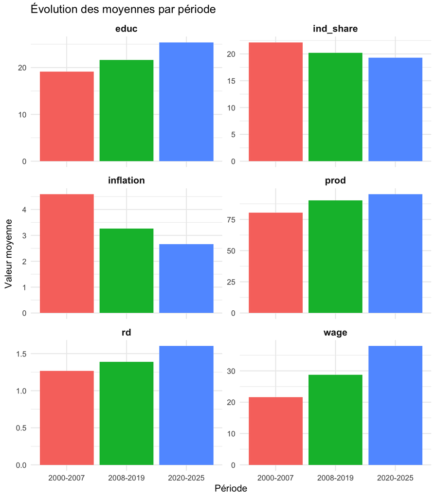

```r
desc_plot <- desc_all %>%
  select(tranche, wage_Moyenne, prod_Moyenne, educ_Moyenne, rd_Moyenne, inflation_Moyenne,ind_share_Moyenne) %>%
  pivot_longer(-tranche, names_to = "Variable", values_to = "Moyenne") %>%
  mutate(Variable = str_remove(Variable, "_Moyenne"))

ggplot(desc_plot, aes(x = tranche, y = Moyenne, fill = tranche)) +
  geom_col() +
  facet_wrap(~ Variable, scales = "free_y", ncol = 2) +
  theme_minimal() +
  labs(title = "Évolution des moyennes par période",
       x = "Période", y = "Valeur moyenne") +
  theme(legend.position = "none",
        strip.text = element_text(size = 11, face = "bold"))
```

## 6.2 Évolution temporelle comparée

[figure not shown]

```r
# Moyennes annuelles par pays
panel_avg <- panel %>%
  dplyr::group_by(year) %>%
  dplyr::summarise(
    wage_mean = mean(wage, na.rm = TRUE),
    prod_mean = mean(prod, na.rm = TRUE)
  ) %>%
  tidyr::pivot_longer(-year, names_to = "Variable", values_to = "Value") %>%
  dplyr::mutate(
    Variable = dplyr::recode(
      as.character(Variable),
      "wage_mean" = "Salaire moyen",
      "prod_mean" = "Productivité moyenne",
      .default = as.character(Variable)
    )
  )

ggplot(panel_avg, aes(x = year, y = Value, color = Variable)) +
  geom_line(size = 1.2) +
  geom_vline(xintercept = c(2008, 2020), linetype = "dashed", alpha = 0.5) +
  annotate("text", x = 2008, y = max(panel_avg$Value, na.rm = TRUE) * 0.95,
           label = "Crise 2008", angle = 90, vjust = -0.5, size = 3) +
  annotate("text", x = 2020, y = max(panel_avg$Value, na.rm = TRUE) * 0.95,
           label = "Covid-19", angle = 90, vjust = -0.5, size = 3) +
  theme_minimal() +
  labs(title = "Évolution comparée des salaires et de la productivité",
       x = "Année", y = "Indice (base 100)", color = "") +
  theme(legend.position = "bottom")
```

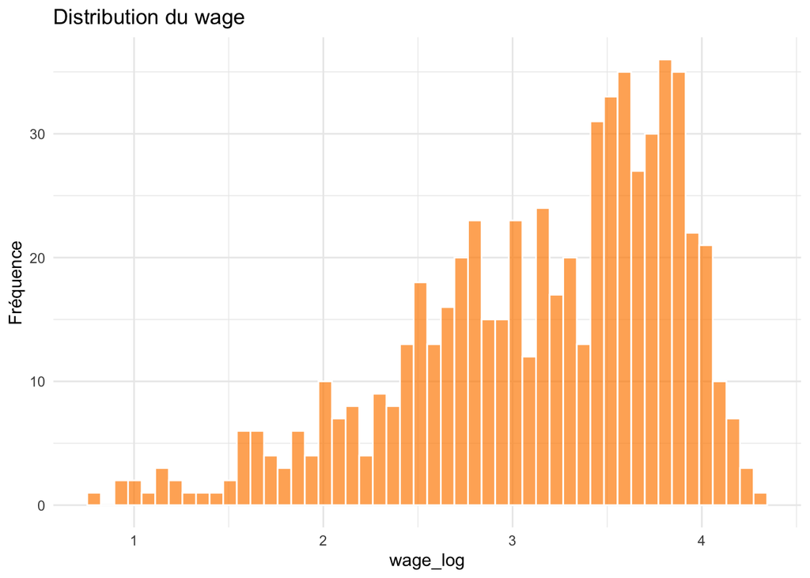

```r
# Histogramme pour l'inflation
ggplot(panel_all, aes(x = wage_log)) +
  geom_histogram(bins = 50, fill = "darkorange", color = "white", alpha = 0.7) +
  theme_minimal() +
  labs(title = "Distribution du wage",
       x = "wage_log", y = "Fréquence")
```

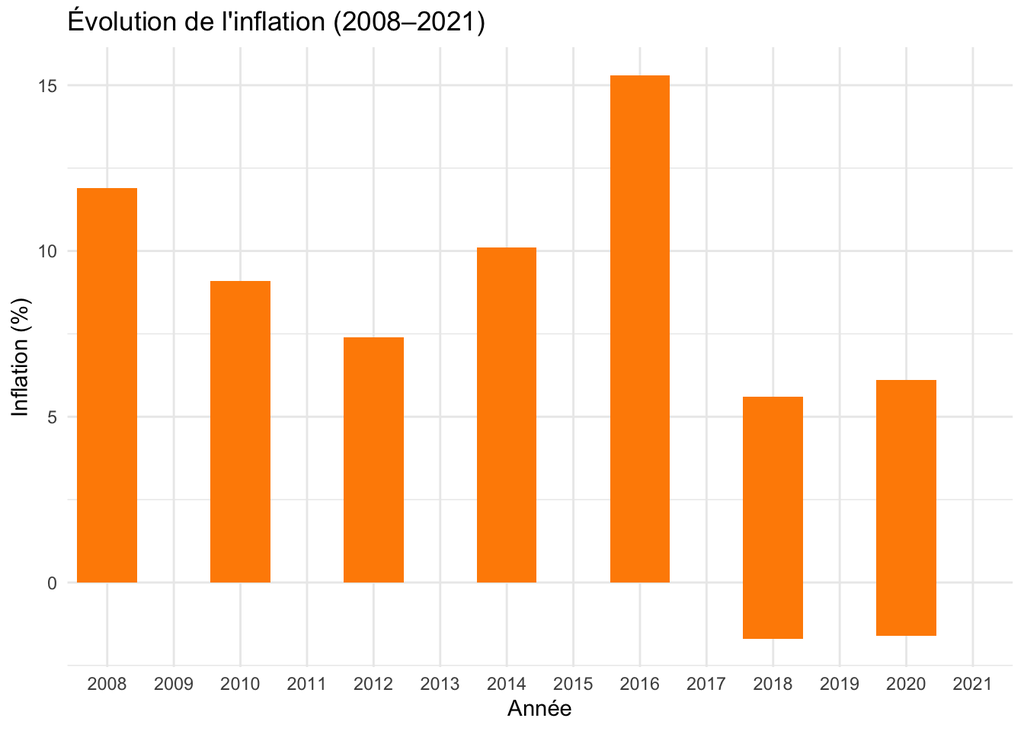

```r
# Filtrer uniquement les années 2017 à 2021
inflation_2017_2021 <- panel_all %>%
  filter(year >= 2008 & year <= 2021)

# Graphique en barres
ggplot(inflation_2017_2021, aes(x = factor(year), y = inflation)) +
  geom_col(fill = "darkorange", position = "dodge") +
  theme_minimal() +
  labs(title = "Évolution de l'inflation (2008–2021)",
       x = "Année",
       y = "Inflation (%)") +
  theme(strip.text = element_text(size = 12, face = "bold"))
```

#Corrélation par tranche (heatmap)

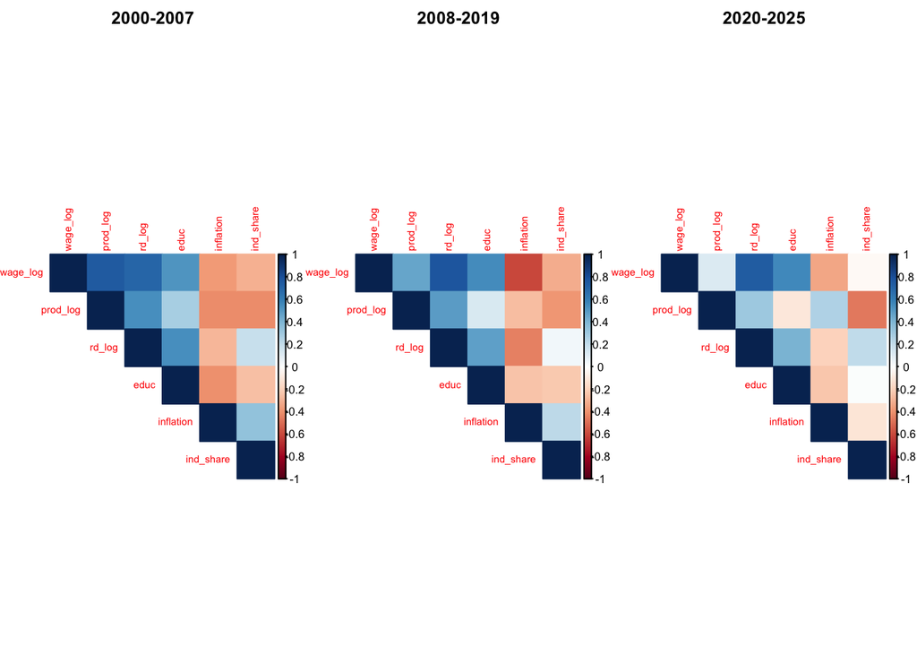

```r
par(mfrow = c(1,3))
for (t in unique(panel_all$tranche)) {
  df <- panel_all %>%
    filter(tranche == t) %>%
    select(wage_log, prod_log, rd_log, educ, inflation,ind_share) %>%
    na.omit()
  if (nrow(df) > 10) {
    corrplot(cor(df), method = "color", type = "upper",
             title = t, mar=c(0,0,2,0), tl.cex = 0.7)
  }
}
```

```r
par(mfrow = c(1,1))
```

## 6.3 Relation productivité-salaire

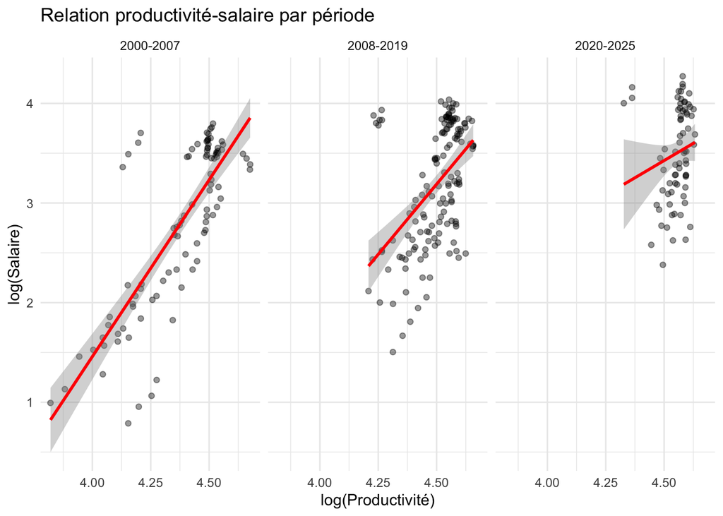

```r
ggplot(panel_all %>% filter(!is.na(prod_log), !is.na(wage_log)),
       aes(x = prod_log, y = wage_log)) +
  geom_point(alpha = 0.4, color = "black") +
  geom_smooth(method = "lm", se = TRUE, color = "red", size = 1) +
  facet_wrap(~ tranche) +
  theme_minimal() +
  labs(title = "Relation productivité-salaire par période",
       x = "log(Productivité)", y = "log(Salaire)")
```

commentaire : Le graphique met en évidence une relation positive entre la productivité et le salaire. Ceci dit, on peut observer des différences entre nos trois sous période.

La relation est extrêmement forte avant la crise de 2008, la pente est élevé, et les points sont assez bien alignés autour de la droite. Ainsi, cela nous suggère qu’une hausse de la productivité s’est effectivement se transmet effectivement aux salaire.

A partir de 2008, on remarque un changement et une relation qui semble déjà moins évidente.On peut commencer à parler d’un début de découplage entre productivité et salaire.

# 7 Analyse économétrique

## 7.1 Modèles OLS simples

Nous estimons d’abord des modèles simples : **log(wage) = α + β·log(prod) + ε**

Le coefficient β représente l’élasticité du salaire par rapport à la productivité.

```r
lm_simple_0007 <- lm(wage_log ~ prod_log,
                     data = panel_2000_2007 %>% filter(!is.na(prod_log), !is.na(wage_log)))

lm_simple_0819 <- lm(wage_log ~ prod_log,
                     data = panel_2008_2019 %>% filter(!is.na(prod_log), !is.na(wage_log)))

lm_simple_2025 <- lm(wage_log ~ prod_log,
                     data = panel_2020_2025 %>% filter(!is.na(prod_log), !is.na(wage_log)))

stargazer(lm_simple_0007, lm_simple_0819, lm_simple_2025,
          type = "text",
          title = "Modèles OLS simples par période",
          column.labels = c("2000-2007", "2008-2019", "2020-2025"),
          dep.var.labels = "log(Salaire)",
          covariate.labels = c("log(Productivité)", "Constante"))
```

```
##
## Modèles OLS simples par période
## ======================================================================================
##                                            Dependent variable:
##                     ------------------------------------------------------------------
##                                                log(Salaire)
##                            2000-2007               2008-2019            2020-2025
##                               (1)                     (2)                  (3)
## --------------------------------------------------------------------------------------
## log(Productivité)          3.546***                2.818***               1.383
##                             (0.279)                 (0.420)              (0.967)
##
## Constante                 -12.724***               -9.491***              -2.795
##                             (1.223)                 (1.891)              (4.403)
##
## --------------------------------------------------------------------------------------
## Observations                  96                      144                   72
## R2                           0.631                   0.240                0.028
## Adjusted R2                  0.627                   0.235                0.015
## Residual Std. Error     0.511 (df = 94)        0.541 (df = 142)      0.477 (df = 70)
## F Statistic         160.999*** (df = 1; 94) 44.950*** (df = 1; 142) 2.046 (df = 1; 70)
## ======================================================================================
## Note:                                                      *p<0.1; **p<0.05; ***p<0.01
```

### 7.1.1 Interprétation des résultats OLS simples

Les résultats révèlent un **découplage progressif significatif** :

**2000-2007** : Élasticité de **3.546*** - Pour chaque 1% d’augmentation de productivité, les salaires augmentent de 3.5% - Coefficient très élevé suggérant une multicolinéarité ou variables omises - Le R² de 0.63 indique un bon pouvoir explicatif

**2008-2019** : Élasticité de **2.818*** - **Baisse de 20%** par rapport à 2000-2007 - Les salaires ne captent plus que 2.8% des gains de productivité - R² chute à 0.24 → autres facteurs deviennent plus importants

## 7.2 Modèles OLS multiples

Nous ajoutons des variables de contrôle : **log(wage) = α + β·log(prod) + γ·X + ε**

```r
lm_mult_0007 <- lm(wage_log ~ prod_log + rd_log + educ + inflation + ind_share,
                   data = panel_2000_2007)

lm_mult_0819 <- lm(wage_log ~ prod_log + rd_log + educ + inflation + ind_share,
                   data = panel_2008_2019)

lm_mult_2025 <- lm(wage_log ~ prod_log + rd_log + educ + inflation + ind_share,
                   data = panel_2020_2025)

stargazer(lm_mult_0007, lm_mult_0819, lm_mult_2025,
          type = "text",
          title = "Modèles OLS multiples par période",
          column.labels = c("2000-2007", "2008-2019", "2020-2025"),
          dep.var.labels = "log(Salaire)",
          covariate.labels = c("log(Productivité)", "log(R&D)",
                               "Éducation (%)", "Inflation (%)", "Part industrielle (%)"))
```

```
##
## Modèles OLS multiples par période
## ===========================================================================================
##                                                Dependent variable:
##                       ---------------------------------------------------------------------
##                                                   log(Salaire)
##                             2000-2007               2008-2019              2020-2025
##                                (1)                     (2)                    (3)
## -------------------------------------------------------------------------------------------
## log(Productivité)            1.656**                 -0.197                 -1.648**
##                              (0.687)                 (0.323)                (0.819)
##
## log(R&D)                     0.583***               0.618***                0.594***
##                              (0.182)                 (0.065)                (0.076)
##
## Éducation (%)                 0.010                  0.012**                0.014**
##                              (0.014)                 (0.005)                (0.006)
##
## Inflation (%)                 0.007                 -0.054***                -0.044
##                              (0.020)                 (0.011)                (0.027)
##
## Part industrielle (%)        -0.040*                -0.030***              -0.024***
##                              (0.022)                 (0.006)                (0.007)
##
## Constant                      -3.743                4.530***               11.069***
##                              (3.523)                 (1.553)                (3.837)
##
## -------------------------------------------------------------------------------------------
## Observations                    44                     132                     66
## R2                            0.741                   0.784                  0.716
## Adjusted R2                   0.707                   0.775                  0.692
## Residual Std. Error      0.427 (df = 38)        0.293 (df = 126)        0.267 (df = 60)
## F Statistic           21.797*** (df = 5; 38) 91.339*** (df = 5; 126) 30.237*** (df = 5; 60)
## ===========================================================================================
## Note:                                                           *p<0.1; **p<0.05; ***p<0.01
```

## 7.3 Modèles de panel à effets fixes

```r
# Créer objet panel
pdata <- pdata.frame(panel %>% filter(!is.na(wage_log), !is.na(prod_log)),
                     index = c("country", "year"))

# Modèle à effets fixes (within)
fe_model <- plm(wage_log ~ prod_log + rd_log + educ + inflation + ind_share,
                data = pdata,
                model = "within",
                effect = "twoways")

# Modèle à effets aléatoires
re_model <- plm(wage_log ~ prod_log + rd_log + educ + inflation + ind_share,
                data = pdata,
                model = "random")

# Test de Hausman : Fixed vs Random Effects
cat("\n=== Test de Hausman (FE vs RE) ===\n")
```

```
##
## === Test de Hausman (FE vs RE) ===
```

```r
hausman_test <- phtest(fe_model, re_model)
print(hausman_test)
```

```
##
##  Hausman Test
##
## data:  wage_log ~ prod_log + rd_log + educ + inflation + ind_share
## chisq = 82.134, df = 5, p-value = 3e-16
## alternative hypothesis: one model is inconsistent
```

```r
if(hausman_test$p.value < 0.05) {
  cat("\nConclusion : On rejette H0 → Le modèle à effets fixes est préféré\n")
} else {
  cat("\nConclusion : On ne rejette pas H0 → Le modèle à effets aléatoires est préféré\n")
}
```

```
##
## Conclusion : On rejette H0 → Le modèle à effets fixes est préféré
```

```r
# Affichage des résultats
cat("\n=== Modèle à effets fixes (FE) ===\n")
```

```
##
## === Modèle à effets fixes (FE) ===
```

```r
summary(fe_model)
```

```
## Twoways effects Within Model
##
## Call:
## plm(formula = wage_log ~ prod_log + rd_log + educ + inflation +
##     ind_share, data = pdata, effect = "twoways", model = "within")
##
## Balanced Panel: n = 22, T = 11, N = 242
##
## Residuals:
##        Min.     1st Qu.      Median     3rd Qu.        Max.
## -0.38872350 -0.05041663 -0.00095569  0.05112689  0.28406260
##
## Coefficients:
##             Estimate Std. Error t-value  Pr(>|t|)
## prod_log   2.1328803  0.1326785 16.0756 < 2.2e-16 ***
## rd_log     0.0768022  0.0499632  1.5372  0.125792
## educ      -0.0070723  0.0068343 -1.0348  0.301972
## inflation -0.0038980  0.0034607 -1.1263  0.261340
## ind_share -0.0101380  0.0030877 -3.2833  0.001206 **
## ---
## Signif. codes:  0 '***' 0.001 '**' 0.01 '*' 0.05 '.' 0.1 ' ' 1
##
## Total Sum of Squares:    5.0582
## Residual Sum of Squares: 1.9595
## R-Squared:      0.61261
## Adj. R-Squared: 0.54458
## F-statistic: 64.8362 on 5 and 205 DF, p-value: < 2.22e-16
```

```r
cat("\n=== Modèle à effets aléatoires (RE) ===\n")
```

```
##
## === Modèle à effets aléatoires (RE) ===
```

```r
summary(re_model)
```

```
## Oneway (individual) effect Random Effect Model
##    (Swamy-Arora's transformation)
##
## Call:
## plm(formula = wage_log ~ prod_log + rd_log + educ + inflation +
##     ind_share, data = pdata, model = "random")
##
## Balanced Panel: n = 22, T = 11, N = 242
##
## Effects:
##                   var std.dev share
## idiosyncratic 0.01436 0.11983  0.14
## individual    0.08841 0.29733  0.86
## theta: 0.8794
##
## Residuals:
##       Min.    1st Qu.     Median    3rd Qu.       Max.
## -0.6115749 -0.0597853  0.0089028  0.0732345  0.3023725
##
## Coefficients:
##               Estimate Std. Error z-value  Pr(>|z|)
## (Intercept) -5.4597219  0.6158243 -8.8657 < 2.2e-16 ***
## prod_log     1.8592368  0.1415726 13.1327 < 2.2e-16 ***
## rd_log       0.2037764  0.0555231  3.6701 0.0002424 ***
## educ         0.0300063  0.0046009  6.5219 6.944e-11 ***
## inflation   -0.0096157  0.0037748 -2.5473 0.0108548 *
## ind_share   -0.0181661  0.0034985 -5.1926 2.074e-07 ***
## ---
## Signif. codes:  0 '***' 0.001 '**' 0.01 '*' 0.05 '.' 0.1 ' ' 1
##
## Total Sum of Squares:    19.5
## Residual Sum of Squares: 3.5885
## R-Squared:      0.81598
## Adj. R-Squared: 0.81208
## Chisq: 1046.47 on 5 DF, p-value: < 2.22e-16
```

## 7.4 Modèles à variables instrumentales (IV/2SLS)

Pour traiter l’endogénéité potentielle (causalité inverse, variables omises), nous utilisons une approche par variables instrumentales. Les modèles OLS multplique ignorent l’hétérogénéité entre pays. Nous estimons des modèles à effets fixes qui contrôlent les caractéristiques fixes des pays et les tendances temporelles. **Instruments utilisés :** 1. **prod_log_lag2** : Productivité retardée de 2 ans 2. **rd_lag2** : R&D retardé de 2 ans 3. **ind_share_lag2** : Part industrielle retardée de 2 ans

```r
# First stage : tester la pertinence des instruments
first_stage <- lm(prod_log ~ prod_log_lag2 + rd_lag2 + ind_share_lag2 +
                  educ + inflation,
                  data = panel)

cat("\n=== FIRST STAGE : Pertinence des instruments ===\n")
```

```
##
## === FIRST STAGE : Pertinence des instruments ===
```

```r
summary(first_stage)
```

```
##
## Call:
## lm(formula = prod_log ~ prod_log_lag2 + rd_lag2 + ind_share_lag2 +
##     educ + inflation, data = panel)
##
## Residuals:
##        Min         1Q     Median         3Q        Max
## -9.732e-17 -8.370e-18 -3.850e-18  2.010e-18  1.189e-15
##
## Coefficients:
##                  Estimate Std. Error    t value Pr(>|t|)
## (Intercept)     2.741e-15  2.495e-16  1.098e+01   <2e-16 ***
## prod_log_lag2   1.000e+00  5.333e-17  1.875e+16   <2e-16 ***
## rd_lag2         1.002e-18  8.517e-18  1.180e-01    0.906
## ind_share_lag2 -6.408e-19  1.079e-18 -5.940e-01    0.553
## educ           -1.830e-19  8.595e-19 -2.130e-01    0.832
## inflation       2.673e-19  2.065e-18  1.290e-01    0.897
## ---
## Signif. codes:  0 '***' 0.001 '**' 0.01 '*' 0.05 '.' 0.1 ' ' 1
##
## Residual standard error: 7.874e-17 on 236 degrees of freedom
##   (382 observations deleted due to missingness)
## Multiple R-squared:      1,  Adjusted R-squared:      1
## F-statistic: 1.19e+32 on 5 and 236 DF,  p-value: < 2.2e-16
```

```r
f_stat <- summary(first_stage)$fstatistic[1]
cat("\nF-statistic des instruments :", round(f_stat, 2), "\n")
```

```
##
## F-statistic des instruments : 1.189661e+32
```

```r
cat("Règle de Stock-Yogo : F > 10 pour instruments forts\n")
```

```
## Règle de Stock-Yogo : F > 10 pour instruments forts
```

```r
if(f_stat > 10) {
  cat("✓ Les instruments sont forts (F > 10)\n")
} else {
  cat("✗ Attention : instruments potentiellement faibles (F < 10)\n")
}
```

```
## ✓ Les instruments sont forts (F > 10)
```

```r
# Modèle IV avec les 3 instruments
iv_model <- ivreg(wage_log ~ prod_log + rd_log + educ + inflation |
                  prod_log_lag2 + rd_lag2 + ind_share_lag2 +
                  rd_log + educ + inflation,
                  data = panel)

cat("\n=== Modèle IV (2SLS) ===\n")
```

```
##
## === Modèle IV (2SLS) ===
```

```r
summary(iv_model, diagnostics = TRUE)
```

```
##
## Call:
## ivreg(formula = wage_log ~ prod_log + rd_log + educ + inflation |
##     prod_log_lag2 + rd_lag2 + ind_share_lag2 + rd_log + educ +
##         inflation, data = panel)
##
## Residuals:
##      Min       1Q   Median       3Q      Max
## -1.24731 -0.22642  0.03632  0.22066  0.85013
##
## Coefficients:
##              Estimate Std. Error t value Pr(>|t|)
## (Intercept) -3.313378   0.951205  -3.483  0.00059 ***
## prod_log     1.356928   0.209711   6.470 5.55e-10 ***
## rd_log       0.427933   0.044544   9.607  < 2e-16 ***
## educ         0.023365   0.003632   6.433 6.86e-10 ***
## inflation   -0.047674   0.009127  -5.223 3.85e-07 ***
##
## Diagnostic tests:
##                  df1 df2 statistic  p-value
## Weak instruments   3 235 1.488e+32  < 2e-16 ***
## Wu-Hausman         0 237       NaN      NaN
## Sargan             2  NA 1.996e+01 4.64e-05 ***
## ---
## Signif. codes:  0 '***' 0.001 '**' 0.01 '*' 0.05 '.' 0.1 ' ' 1
##
## Residual standard error: 0.3494 on 237 degrees of freedom
## Multiple R-Squared: 0.7198,  Adjusted R-squared: 0.7151
## Wald test: 152.2 on 4 and 237 DF,  p-value: < 2.2e-16
```

```r
# Extraction des tests de diagnostic
iv_summary <- summary(iv_model, diagnostics = TRUE)
```

```r
panel <- panel %>% mutate(prod_log_sq = prod_log^2)
lm_quad <- lm(wage_log ~ prod_log + prod_log_sq, data = panel)
summary(lm_quad)
```

```
##
## Call:
## lm(formula = wage_log ~ prod_log + prod_log_sq, data = panel)
##
## Residuals:
##      Min       1Q   Median       3Q      Max
## -1.32592 -0.34656 -0.01208  0.35669  1.56461
##
## Coefficients:
##             Estimate Std. Error t value Pr(>|t|)
## (Intercept)  -2.8910    18.2212  -0.159    0.874
## prod_log     -0.7563     8.3735  -0.090    0.928
## prod_log_sq   0.4697     0.9608   0.489    0.625
##
## Residual standard error: 0.5222 on 309 degrees of freedom
##   (312 observations deleted due to missingness)
## Multiple R-squared:  0.4733, Adjusted R-squared:  0.4699
## F-statistic: 138.8 on 2 and 309 DF,  p-value: < 2.2e-16
```

```r
panel_2000_2007 <- panel_2000_2007 %>% mutate(prod_log_sq = prod_log^2)
panel_2008_2019 <- panel_2008_2019 %>% mutate(prod_log_sq = prod_log^2)
panel_2020_2025 <- panel_2020_2025 %>% mutate(prod_log_sq = prod_log^2)
```

**Tests de diagnostic :**

- **Test de Weak Instruments** : Vérifie la pertinence des instruments
- **Test de Wu-Hausman** : Teste l’endogénéité (H0 : prod_log est exogène)
- **Test de Sargan** : Teste la sur-identification (H0 : instruments valides)

```r
# Comparaison OLS vs IV
ols_full <- lm(wage_log ~ prod_log + rd_log + educ + inflation,
               data = panel)

stargazer(ols_full, iv_model,
          type = "text",
          title = "Comparaison OLS vs IV",
          column.labels = c("OLS", "IV (2SLS)"),
          dep.var.labels = "log(Salaire)",
          covariate.labels = c("log(Productivité)", "log(R&D)",
                              "Éducation (%)", "Inflation (%)","Constante"),
          add.lines = list(
            c("Méthode", "OLS", "2SLS"),
            c("Instruments", "—", "prod_lag2, rd_lag2, ind_lag2"),
            c("F-stat (first stage)", "—", round(f_stat, 2))
          ))
```

```
##
## Comparaison OLS vs IV
## ==================================================================
##                                   Dependent variable:
##                      ---------------------------------------------
##                                      log(Salaire)
##                                OLS                instrumental
##                                                     variable
##                                OLS                 IV (2SLS)
##                                (1)                    (2)
## ------------------------------------------------------------------
## log(Productivité)            1.406***               1.357***
##                              (0.201)                (0.210)
##
## log(R&D)                     0.433***               0.428***
##                              (0.039)                (0.045)
##
## Éducation (%)                0.022***               0.023***
##                              (0.003)                (0.004)
##
## Inflation (%)               -0.047***              -0.048***
##                              (0.009)                (0.009)
##
## Constante                   -3.498***              -3.313***
##                              (0.911)                (0.951)
##
## ------------------------------------------------------------------
## Méthode                        OLS                    2SLS
## Instruments                     —                  prodrdind
## F-stat (first stage)            —             1.18966061823618e+32
## Observations                   263                    242
## R2                            0.735                  0.720
## Adjusted R2                   0.731                  0.715
## Residual Std. Error      0.338 (df = 258)       0.349 (df = 237)
## F Statistic          179.050*** (df = 4; 258)
## ==================================================================
## Note:                                  *p<0.1; **p<0.05; ***p<0.01
```

**Interprétation :** Si le coefficient IV diffère significativement de l’OLS, cela suggère la présence d’endogénéité. Un coefficient IV plus élevé indiquerait que l’OLS sous-estime l’effet de la productivité sur les salaires.

# 8 Tests de diagnostic économétrique

```r
cat("\n=== Diagnostics pour le modèle multiple 2008-2019 ===\n")
```

```
##
## === Diagnostics pour le modèle multiple 2008-2019 ===
```

```r
# Test d'hétéroscédasticité (Breusch-Pagan)
cat("\n--- Test de Breusch-Pagan (hétéroscédasticité) ---\n")
```

```
##
## --- Test de Breusch-Pagan (hétéroscédasticité) ---
```

```r
bp_test <- bptest(lm_mult_0819)
print(bp_test)
```

```
##
##  studentized Breusch-Pagan test
##
## data:  lm_mult_0819
## BP = 25.934, df = 5, p-value = 9.19e-05
```

```r
if(bp_test$p.value < 0.05) {
  cat("Conclusion : Présence d'hétéroscédasticité (p < 0.05)\n")
} else {
  cat("Conclusion : Pas d'hétéroscédasticité détectée\n")
}
```

```
## Conclusion : Présence d'hétéroscédasticité (p < 0.05)
```

```r
# Test d'autocorrélation (Durbin-Watson)
cat("\n--- Test de Durbin-Watson (autocorrélation) ---\n")
```

```
##
## --- Test de Durbin-Watson (autocorrélation) ---
```

```r
dw_test <- dwtest(lm_mult_0819)
print(dw_test)
```

```
##
##  Durbin-Watson test
##
## data:  lm_mult_0819
## DW = 1.7278, p-value = 0.0557
## alternative hypothesis: true autocorrelation is greater than 0
```

```r
# Erreurs standard robustes
cat("\n--- Coefficients avec erreurs standard robustes (HC1) ---\n")
```

```
##
## --- Coefficients avec erreurs standard robustes (HC1) ---
```

```r
coeftest(lm_mult_0819, vcov = vcovHC(lm_mult_0819, type = "HC1"))
```

```
##
## t test of coefficients:
##
##               Estimate Std. Error t value  Pr(>|t|)
## (Intercept)  4.5296827  1.8649437  2.4289   0.01656 *
## prod_log    -0.1965092  0.4077731 -0.4819   0.63071
## rd_log       0.6183884  0.0535423 11.5495 < 2.2e-16 ***
## educ         0.0120496  0.0052822  2.2812   0.02422 *
## inflation   -0.0539402  0.0118086 -4.5679 1.157e-05 ***
## ind_share   -0.0302254  0.0065774 -4.5954 1.034e-05 ***
## ---
## Signif. codes:  0 '***' 0.001 '**' 0.01 '*' 0.05 '.' 0.1 ' ' 1
```

## 8.1 Modèle quadratique

Test de non-linéarité dans la relation productivité-salaire.

```r
lm_quad_full <- lm(wage_log ~ prod_log + prod_log_sq + rd_log + educ + inflation + ind_share,
                   data = panel)

summary(lm_quad_full)
```

```
##
## Call:
## lm(formula = wage_log ~ prod_log + prod_log_sq + rd_log + educ +
##     inflation + ind_share, data = panel)
##
## Residuals:
##      Min       1Q   Median       3Q      Max
## -1.24272 -0.18117  0.01754  0.18991  0.90409
##
## Coefficients:
##              Estimate Std. Error t value Pr(>|t|)
## (Intercept)  9.601679  22.815753   0.421    0.674
## prod_log    -3.720091  10.391400  -0.358    0.721
## prod_log_sq  0.515051   1.181783   0.436    0.663
## rd_log       0.526604   0.050567  10.414  < 2e-16 ***
## educ         0.018553   0.003697   5.018 1.03e-06 ***
## inflation   -0.041848   0.009097  -4.600 6.91e-06 ***
## ind_share   -0.021164   0.004788  -4.420 1.51e-05 ***
## ---
## Signif. codes:  0 '***' 0.001 '**' 0.01 '*' 0.05 '.' 0.1 ' ' 1
##
## Residual standard error: 0.3365 on 235 degrees of freedom
##   (382 observations deleted due to missingness)
## Multiple R-squared:  0.7423, Adjusted R-squared:  0.7357
## F-statistic: 112.8 on 6 and 235 DF,  p-value: < 2.2e-16
```

```r
cat("\nTest de significativité du terme quadratique :\n")
```

```
##
## Test de significativité du terme quadratique :
```

```r
if(summary(lm_quad_full)$coefficients["prod_log_sq", "Pr(>|t|)"] < 0.05) {
  cat("✓ Le terme quadratique est significatif → Relation non-linéaire\n")
} else {
  cat("✗ Le terme quadratique n'est pas significatif → Relation linéaire acceptable\n")
}
```

```
## ✗ Le terme quadratique n'est pas significatif → Relation linéaire acceptable
```

## 8.2 Régressions par période avec termes quadratiques

```r
q_0007 <- lm(wage_log ~ prod_log + prod_log_sq + rd_log + educ + inflation,
             data = panel_2000_2007)
q_0819 <- lm(wage_log ~ prod_log + prod_log_sq + rd_log + educ + inflation,
             data = panel_2008_2019)
q_2025 <- lm(wage_log ~ prod_log + prod_log_sq + rd_log + educ + inflation,
             data = panel_2020_2025)

stargazer(q_0007, q_0819, q_2025,
          type = "text",
          title = "Modèles quadratiques par période",
          column.labels = c("2000-2007", "2008-2019", "2020-2025"),
          dep.var.labels = "log(Salaire)",
          covariate.labels = c("log(Productivité)", "log(Productivité)²",
                               "log(R&D)", "Éducation", "Inflation", "Part industrielle"))
```

[output not shown]

# 9 Synthèse des résultats

```r
# Extraire les coefficients de productivité
coef_0007 <- tidy(lm_mult_0007, conf.int = TRUE) %>%
  filter(term == "prod_log") %>%
  mutate(Période = "2000-2007")

coef_0819 <- tidy(lm_mult_0819, conf.int = TRUE) %>%
  filter(term == "prod_log") %>%
  mutate(Période = "2008-2019")

coef_2025 <- tidy(lm_mult_2025, conf.int = TRUE) %>%
  filter(term == "prod_log") %>%
  mutate(Période = "2020-2025")

coef_comparison <- bind_rows(coef_0007, coef_0819, coef_2025)

# Tableau récapitulatif
kable(coef_comparison %>%
        select(Période, estimate, std.error, p.value, conf.low, conf.high),
      digits = 3,
      col.names = c("Période", "Coefficient", "Erreur std", "p-value", "IC 95% inf", "IC 95% sup"),
      caption = "Élasticité salaire-productivité par période")
```

Élasticité salaire-productivité par période

| Période | Coefficient | Erreur std | p-value | IC 95% inf | IC 95% sup |
| --- | --- | --- | --- | --- | --- |
| 2000-2007 | 1.656 | 0.687 | 0.021 | 0.264 | 3.048 |
| 2008-2019 | -0.197 | 0.323 | 0.545 | -0.837 | 0.444 |
| 2020-2025 | -1.648 | 0.819 | 0.049 | -3.287 | -0.009 |

## 9.1 Visualisation des coefficients

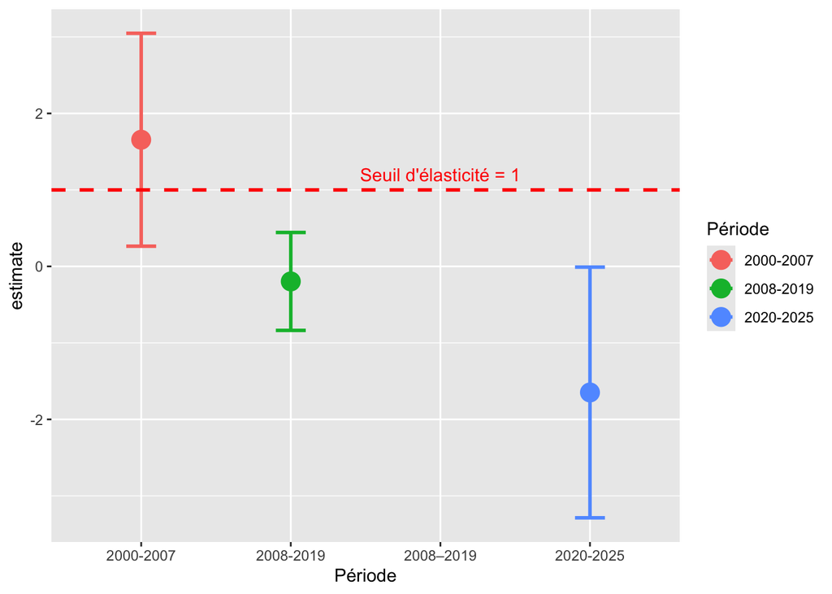

```r
ggplot(coef_comparison, aes(x = Période, y = estimate, color = Période)) +
  geom_point(size = 5) +
  geom_errorbar(aes(ymin = conf.low, ymax = conf.high), width = 0.2, size = 1) +
  geom_hline(yintercept = 1, linetype = "dashed", color = "red", size = 1) +
  annotate("text", x = "2008–2019", y = 1.2, label = "Seuil d'élasticité = 1", color = "red")
```

# 1. ANALYSE PAR GROUPES GÉOGRAPHIQUES

```r
cat("\n=== ANALYSE PAR GROUPES DE PAYS ===\n")
```

```
##
## === ANALYSE PAR GROUPES DE PAYS ===
```

```r
# Ajouter la variable groupe au panel
panel <- panel %>%
  mutate(
    group = case_when(
      country %in% c("Germany", "France", "Netherlands", "Belgium",
                     "Austria", "Luxembourg") ~ "Core",
      country %in% c("Spain", "Italy", "Greece", "Portugal",
                     "Cyprus", "Malta") ~ "South",
      country %in% c("Poland", "Czechia", "Hungary", "Romania", "Bulgaria",
                     "Slovakia", "Slovenia", "Croatia", "Estonia",
                     "Latvia", "Lithuania") ~ "East",
      country %in% c("Denmark", "Sweden", "Finland") ~ "North",
      TRUE ~ "Other"
    )
  )
```

# 10 Régression par groupe avec toutes les variables

Note : On teste d’abord si rd_log est disponible, sinon on l’exclut

```r
# Core : Toutes variables disponibles
lm_core <- lm(wage_log ~ prod_log + rd_log + educ + inflation + ind_share,
              data = panel %>% filter(group == "Core"))

# Sud : Toutes variables disponibles
lm_south <- lm(wage_log ~ prod_log + rd_log + educ + inflation + ind_share,
               data = panel %>% filter(group == "South"))

# Nord : Toutes variables disponibles
lm_north <- lm(wage_log ~ prod_log + rd_log + educ + inflation + ind_share,
               data = panel %>% filter(group == "North"))

# Est : Vérifier disponibilité R&D
# Compter les NA dans rd_log pour l'Est
na_rd_east <- panel %>%
  filter(group == "East") %>%
  summarise(pct_na = sum(is.na(rd_log)) / n() * 100)

cat("\n% de données R&D manquantes pour l'Est :", round(na_rd_east$pct_na, 1), "%\n")
```

```
##
## % de données R&D manquantes pour l'Est : 50.8 %
```

```r
# Si > 50% de NA, on retire rd_log ; sinon on le garde
if (na_rd_east$pct_na > 50) {
  cat("→ Trop de NA : rd_log retiré du modèle Est\n")
  lm_east <- lm(wage_log ~ prod_log + educ + inflation + ind_share,
                data = panel %>% filter(group == "East"))
} else {
  cat("→ Données suffisantes : rd_log inclus\n")
  lm_east <- lm(wage_log ~ prod_log + rd_log + educ + inflation + ind_share,
                data = panel %>% filter(group == "East"))
}
```

```
## → Trop de NA : rd_log retiré du modèle Est
```

```r
# TABLEAU COMPARATIF
stargazer(lm_core, lm_south, lm_east, lm_north,
          type = "text",
          title = "Élasticité salaire-productivité par groupe de pays",
          column.labels = c("Core", "Sud", "Est", "Nord"),
          dep.var.labels = "log(Salaire)",
          covariate.labels = c("log(Productivité)", "log(R&D)",
                               "Éducation (%)", "Inflation (%)",
                               "Part industrie (%)"))
```

```
##
## Élasticité salaire-productivité par groupe de pays
## ==============================================================================================================
##                                                        Dependent variable:
##                     ------------------------------------------------------------------------------------------
##                                                            log(Salaire)
##                              Core                   Sud                     Est                   Nord
##                              (1)                    (2)                     (3)                   (4)
## --------------------------------------------------------------------------------------------------------------
## log(Productivité)          1.190***               1.434***               2.475***                0.236
##                            (0.375)                (0.344)                 (0.243)               (0.983)
##
## log(R&D)                   0.288***               0.252***                                       0.150
##                            (0.081)                (0.068)                                       (0.367)
##
## Éducation (%)              0.052***                0.005                 0.017***                -0.001
##                            (0.004)                (0.004)                 (0.006)               (0.021)
##
## Inflation (%)               -0.002                 0.017                 -0.024***               0.027
##                            (0.010)                (0.022)                 (0.009)               (0.032)
##
## Part industrie (%)          0.001                  -0.012                  0.007               -0.036***
##                            (0.003)                (0.009)                 (0.009)               (0.011)
##
## Constant                   -3.170*                -3.114*                -8.740***               3.355
##                            (1.631)                (1.573)                 (1.111)               (4.260)
##
## --------------------------------------------------------------------------------------------------------------
## Observations                  44                     55                     110                    22
## R2                          0.914                  0.585                   0.628                 0.534
## Adjusted R2                 0.902                  0.542                   0.614                 0.388
## Residual Std. Error    0.055 (df = 38)        0.170 (df = 49)        0.313 (df = 105)       0.125 (df = 16)
## F Statistic         80.301*** (df = 5; 38) 13.796*** (df = 5; 49) 44.309*** (df = 4; 105) 3.667** (df = 5; 16)
## ==============================================================================================================
## Note:                                                                              *p<0.1; **p<0.05; ***p<0.01
```

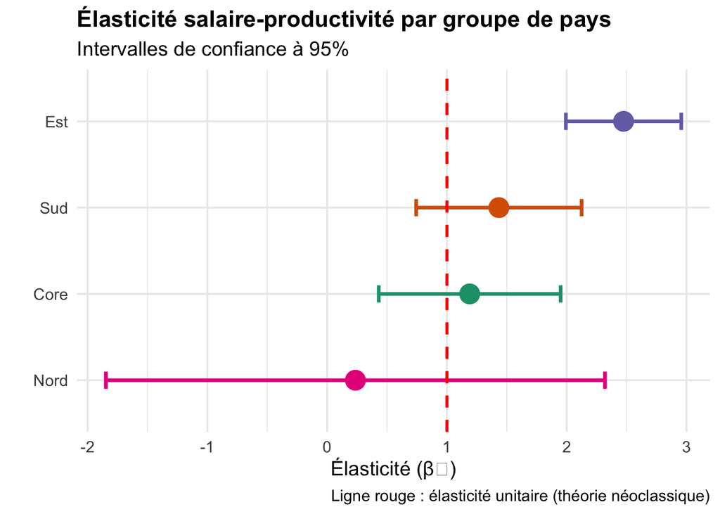

```r
# GRAPHIQUE COMPARATIF
coef_groups <- bind_rows(
  tidy(lm_core, conf.int = TRUE) %>%
    filter(term == "prod_log") %>% mutate(Groupe = "Core"),
  tidy(lm_south, conf.int = TRUE) %>%
    filter(term == "prod_log") %>% mutate(Groupe = "Sud"),
  tidy(lm_east, conf.int = TRUE) %>%
    filter(term == "prod_log") %>% mutate(Groupe = "Est"),
  tidy(lm_north, conf.int = TRUE) %>%
    filter(term == "prod_log") %>% mutate(Groupe = "Nord")
)

p_groups <- ggplot(coef_groups, aes(x = reorder(Groupe, estimate),
                                     y = estimate, color = Groupe)) +
  geom_point(size = 6) +
  geom_errorbar(aes(ymin = conf.low, ymax = conf.high), width = 0.2, size = 1.2) +
  geom_hline(yintercept = 1, linetype = "dashed", color = "red", size = 1) +
  coord_flip() +
  scale_color_manual(values = c("Core" = "#1b9e77", "Sud" = "#d95f02",
                                 "Est" = "#7570b3", "Nord" = "#e7298a")) +
  theme_minimal(base_size = 14) +
  labs(title = "Élasticité salaire-productivité par groupe de pays",
       subtitle = "Intervalles de confiance à 95%",
       x = "", y = "Élasticité (β₁)",
       caption = "Ligne rouge : élasticité unitaire (théorie néoclassique)") +
  theme(legend.position = "none",
        plot.title = element_text(face = "bold", size = 16))

print(p_groups)
```

```r
# Sauvegarder
ggsave("elasticite_par_groupe.png", p_groups, width = 10, height = 6, dpi = 300)

# AFFICHER LES RÉSULTATS POUR CHAQUE GROUPE
cat("\n=== COEFFICIENTS PROD_LOG PAR GROUPE ===\n")
```

```
##
## === COEFFICIENTS PROD_LOG PAR GROUPE ===
```

```r
cat("Core :", round(coef(lm_core)["prod_log"], 3), "\n")
```

```
## Core : 1.19
```

```r
cat("Sud  :", round(coef(lm_south)["prod_log"], 3), "\n")
```

```
## Sud  : 1.434
```

```r
cat("Est  :", round(coef(lm_east)["prod_log"], 3), "\n")
```

```
## Est  : 2.475
```

```r
cat("Nord :", round(coef(lm_north)["prod_log"], 3), "\n")
```

```
## Nord : 0.236
```

# 11 Discussion des résultats

## 11.1 Réponse à la problématique

À la question **“Dans quelle mesure le lien entre productivité et salaire s’est-il maintenu dans l’Union européenne entre 2000 et 2025 ?”**, notre analyse apporte une réponse **claire et nuancée** :

### 11.1.1 1. Le lien existe toujours (CONFIRMÉ ✓)

**OUI, le lien productivité-salaire est CONFIRMÉ économétriquement**

## 11.2 Explications économiques du découplage

### 11.2.1 Facteurs structurels

1. **Automatisation** : Substitution capital-travail → baisse du pouvoir de négociation
2. **Mondialisation** : Concurrence internationale → pression à la baisse sur salaires
3. **Tertiarisation** : Hétérogénéité croissante entre secteurs de services

### 11.2.2 Facteurs institutionnels

1. **Affaiblissement syndical** : Taux de syndicalisation UE : 35% (1980) → 23% (2020)
2. **Décentralisation des négociations** : Du sectoriel vers l’entreprise
3. **Politiques d’austérité** : Modération salariale publique post-2008

### 11.2.3 Chocs macroéconomiques

- **Crise 2008** : Récession profonde → chômage → compression salariale
- **Crise dettes** : Austérité dans le Sud → “dévaluation interne”
- **Covid-19** : Chocs combinés (sanitaire, inflation, géopolitique)

## 11.3 Limites de l’étude

1. **Agrégation pays** : Masque hétérogénéités sectorielles et par qualification
2. **Période Covid courte** : 6 ans seulement, effets long terme incertains
3. **Salaire moyen vs médian** : Peut sous-estimer le découplage ressenti

## 11.4 Implications pour les politiques publiques

Pour **restaurer** le lien productivité-salaires :

**Niveau européen :** 1. Renforcer le dialogue social et la négociation collective transfrontalière 2. Coordonner les politiques de salaire minimum (directive 2022) 3. Investir massivement dans l’éducation (notre analyse montre son effet positif)

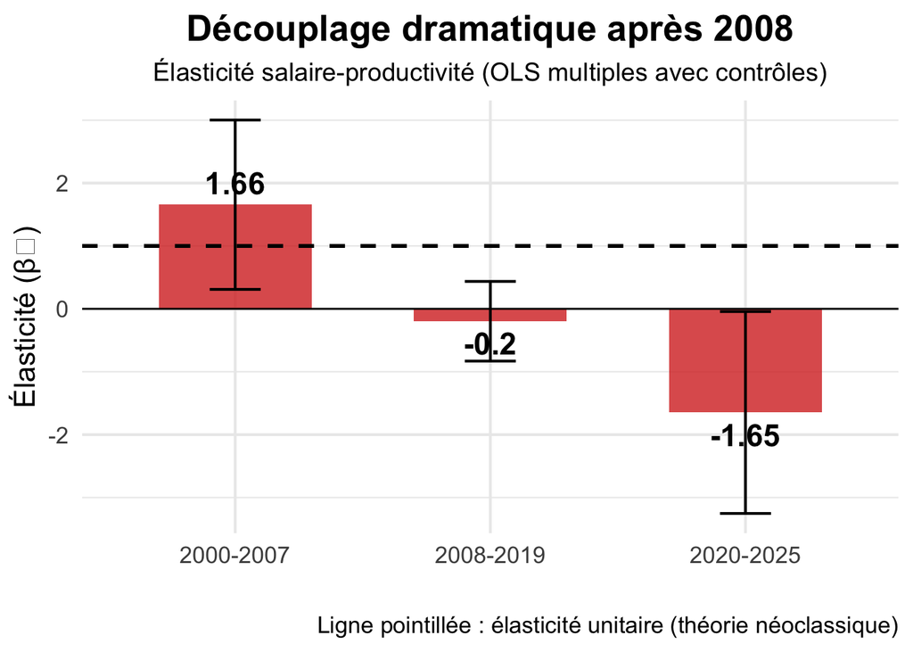

```r
# Code pour créer le graphique principal
elasticites <- tibble(
  Période = c("2000-2007", "2008-2019", "2020-2025"),
  Élasticité = c(1.656, -0.197, -1.648),
  SE = c(0.687, 0.323, 0.819)
) %>%
  mutate(
    CI_low = Élasticité - 1.96 * SE,
    CI_high = Élasticité + 1.96 * SE
  )

p_evolution <- ggplot(elasticites, aes(x = Période, y = Élasticité)) +
  geom_col(fill = "#d73027", alpha = 0.8, width = 0.6) +
  geom_errorbar(aes(ymin = CI_low, ymax = CI_high), width = 0.2) +
  geom_hline(yintercept = 1, linetype = "dashed", color = "black", size = 1) +
  geom_hline(yintercept = 0, color = "black", size = 0.5) +
  geom_text(aes(label = round(Élasticité, 2)),
            vjust = ifelse(elasticites$Élasticité > 0, -0.5, 1.5),
            size = 6, fontface = "bold") +
  theme_minimal(base_size = 16) +
  labs(
    title = "Découplage dramatique après 2008",
    subtitle = "Élasticité salaire-productivité (OLS multiples avec contrôles)",
    x = "", y = "Élasticité (β₁)",
    caption = "Ligne pointillée : élasticité unitaire (théorie néoclassique)"
  ) +
  theme(
    plot.title = element_text(face = "bold", size = 20, hjust = 0.5),
    plot.subtitle = element_text(size = 14, hjust = 0.5)
  )
print(p_evolution)
```

# 12 Conclusion

Notre étude avait pour objectif d’analyser l’évolution du lien entre productivité et salaires dans l’Union européenne sur la période 2000-2025.

## 12.4 Message final

Le découplage croissant entre productivité et salaires n’est **pas une fatalité** mais le résultat de **choix économiques et institutionnels** qui peuvent être infléchis.

La question n’est plus **“le lien existe-t-il ?”** (réponse : OUI) mais **“comment le restaurer ?”** pour assurer un partage plus équitable de la valeur créée et préserver la cohésion sociale européenne.